# TO628 HW3: Prediction of Tele-Marketing Call Success

Mandy Ho

```r
knitr::opts_chunk$set(echo = TRUE)
library(tidyverse, quietly = T)
library(C50, quietly = T)
library(e1071, quietly = T)
library(caret, quietly = T)
library(class, quietly = T)
library(neuralnet, quietly = T)
library(nnet, quietly = T)
library(knitr, quietly = T)
library(rattle, quietly = T)
library(NeuralNetTools, quietly = T)
library(partykit, quietly = T)
```

### I. Objective

Using Logistic Regression, ANN, kNN, SVM and Decision Trees to Predict Tele-Marketing Call Success. For this assignment, we will be looking at Tele-Marketing Data and attempt to predict whether the tele-marketing call will be successful or not.

### II. Assignment Description

1. Use the predictive analytics methodologies that we have learnt so far - Logistic Regression, kNN (k Nearest Neighbors), SVM, ANN and Decision Trees - to build a model that can help us predict whether a tele-marketing call would be successful or not.
2. The end product is a prediction on testing data (which you will create out of this dataset) and an effort to improve the prediction.
3. Create a combined prediction using the Stacked Model methodology.
4. Conclusion section and discuss whether you would want to use the kNN, SVM, ANN or the Combined prediction model to improve the success of the TeleMarketing efforts - and why. Focus on the business problem - the managerial decision making while choosing your preferred model.

### III. Data Description

We have information on more than 41,000 tele-marketing calls made by a bank to sell a product called term deposit. The data has information on which of these calls were actually successful in making a sale. As tele-marketing has very low conversion rates typically, if we can predict whether a customer is likely to buy or not, we can focus our tele-marketing efforts towards more willing buyers and save/make a ton of money.

### IV. Data Variables

##### A. Bank Client Data

1 - age (numeric)  
2 - job : type of job (categorical: ‘admin.’,‘blue-collar’,‘entrepreneur’,‘housemaid’,‘management’,‘retired’,‘self-employed’,‘services’,‘student’,‘technician’,‘unemployed’,‘unknown’)  
3 - marital : marital status (categorical: ‘divorced’,‘married’,‘single’,‘unknown’; note: ‘divorced’ means divorced or widowed)  
4 - education (categorical: ‘basic.4y’,‘basic.6y’,‘basic.9y’,‘high.school’,‘illiterate’,‘professional.course’,‘university.degree’,‘unknown’)  
5 - default: has credit in default? (categorical: ‘no’,‘yes’,‘unknown’)  
6 - housing: has housing loan? (categorical: ‘no’,‘yes’,‘unknown’)  
7 - loan: has personal loan? (categorical: ‘no’,‘yes’,‘unknown’)

##### B. Data related with the last contact of the current campaign

8 - contact: contact communication type (categorical: ‘cellular’,‘telephone’)  
9 - month: last contact month of year (categorical: ‘jan’, ‘feb’, ‘mar’, …, ‘nov’, ‘dec’)  
10 - day_of_week: last contact day of the week (categorical: ‘mon’,‘tue’,‘wed’,‘thu’,‘fri’)  
11 - duration: last contact duration, in seconds (numeric).  
Important note: this attribute highly affects the output target (e.g., if duration=0 then y=‘no’). Yet, the duration is not known before a call is performed. Also, after the end of the call y is obviously known. *Clearly - this variable SHOULD NOT be used in a predictive model. So Don’t Use It!*

##### C. Other Attributes

12 - campaign: number of contacts performed during this campaign and for this client (numeric, includes last contact)  
13 - pdays: number of days that passed by after the client was last contacted from a previous campaign (numeric; 999 means client was not previously contacted)  
14 - previous: number of contacts performed before this campaign and for this client (numeric)  
15 - poutcome: outcome of the previous marketing campaign (categorical: ‘failure’,‘nonexistent’,‘success’)

##### D. Social and economic context attributes

16 - emp.var.rate: employment variation rate - quarterly indicator (numeric)  
17 - cons.price.idx: consumer price index - monthly indicator (numeric)  
18 - cons.conf.idx: consumer confidence index - monthly indicator (numeric)  
19 - euribor3m: euribor 3 month rate - daily indicator (numeric)  
20 - nr.employed: number of employees - quarterly indicator (numeric)

##### E. Output variable (desired target)

21 - y - has the client subscribed a term deposit? (binary: ‘yes’,‘no’)

### V. Load Data and Data Cleaning

```r
tdata = read.csv("tele.csv", header = T, na.strings = c(" ", ''))

# remove "X" and "duration"
sdata = tdata %>% select(-X, -duration)

# recode 999 in pdays to NA
sdata$pdays = ifelse(sdata$pdays == 999,0, 1)
str(sdata)
```

```
## 'data.frame':    41188 obs. of  20 variables:
##  $ age           : int  56 57 37 40 56 45 59 41 24 25 ...
##  $ job           : Factor w/ 12 levels "admin.","blue-collar",..: 4 8 8 1 8 8 1 2 10 8 ...
##  $ marital       : Factor w/ 4 levels "divorced","married",..: 2 2 2 2 2 2 2 2 3 3 ...
##  $ education     : Factor w/ 8 levels "basic.4y","basic.6y",..: 1 4 4 2 4 3 6 8 6 4 ...
##  $ default       : Factor w/ 3 levels "no","unknown",..: 1 2 1 1 1 2 1 2 1 1 ...
##  $ housing       : Factor w/ 3 levels "no","unknown",..: 1 1 3 1 1 1 1 1 3 3 ...
##  $ loan          : Factor w/ 3 levels "no","unknown",..: 1 1 1 1 3 1 1 1 1 1 ...
##  $ contact       : Factor w/ 2 levels "cellular","telephone": 2 2 2 2 2 2 2 2 2 2 ...
##  $ month         : Factor w/ 10 levels "apr","aug","dec",..: 7 7 7 7 7 7 7 7 7 7 ...
##  $ day_of_week   : Factor w/ 5 levels "fri","mon","thu",..: 2 2 2 2 2 2 2 2 2 2 ...
##  $ campaign      : int  1 1 1 1 1 1 1 1 1 1 ...
##  $ pdays         : num  0 0 0 0 0 0 0 0 0 0 ...
##  $ previous      : int  0 0 0 0 0 0 0 0 0 0 ...
##  $ poutcome      : Factor w/ 3 levels "failure","nonexistent",..: 2 2 2 2 2 2 2 2 2 2 ...
##  $ emp.var.rate  : num  1.1 1.1 1.1 1.1 1.1 1.1 1.1 1.1 1.1 1.1 ...
##  $ cons.price.idx: num  94 94 94 94 94 ...
##  $ cons.conf.idx : num  -36.4 -36.4 -36.4 -36.4 -36.4 -36.4 -36.4 -36.4 -36.4 -36.4 ...
##  $ euribor3m     : num  4.86 4.86 4.86 4.86 4.86 ...
##  $ nr.employed   : num  5191 5191 5191 5191 5191 ...
##  $ y             : Factor w/ 2 levels "no","yes": 1 1 1 1 1 1 1 1 1 1 ...
```

```r
# data normalization: z-Score Standardization for dataset
scale.data = as.data.frame(lapply(sdata, function(x) {
  if((class(x[1]) != "numeric") & (class(x[1]) != "integer")) {
    return (x)
  }
  return(scale(x))
}))

# check missing data
if (anyNA(scale.data) == FALSE){
  print("There is no missing data/")
} else{print("Need missing data imputation.")}
```

```
## [1] "There is no missing data/"
```

### VI. Split train and test set

training set: N = 28831  
testing set: N = 12357

```r
# split train and test dataset
set.seed(40)
train_ind = sample(seq_len(nrow(scale.data )), size = as.integer(dim(scale.data )[1]*0.7))

train = sdata[train_ind,]
test = sdata[-train_ind,]
```

### VII. Model Training

```r
glm.model.file = "glm.rds"
svm.linear.file = "svm_linear.rds"
svm.radial.file = "svm_radial.rds"
knn.file = "knn.rds"
ds.tree.file = "ds_tree.rds"
ann.file = "ann.rds"
```

#### 1. Logistic regression

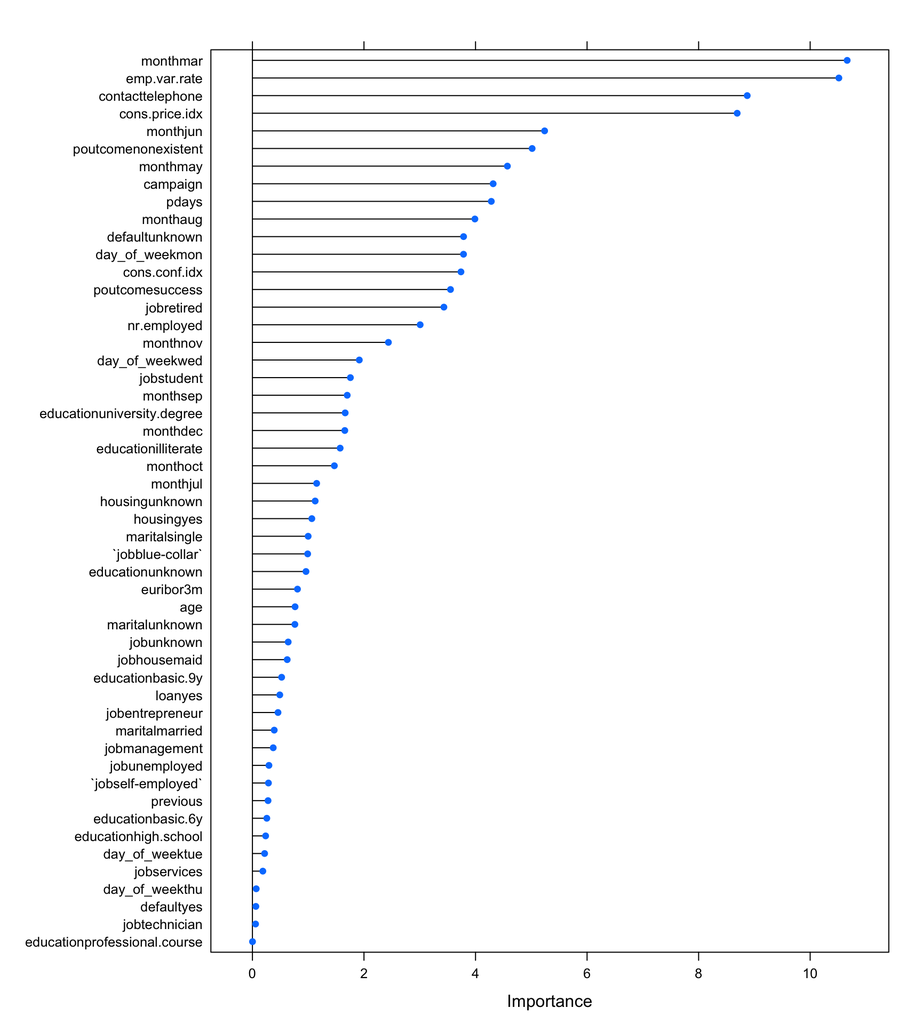

```r
if (file.exists(glm.model.file)){
  glm.model = readRDS(glm.model.file)
} else{
  system.time({
  glm.model = train(form = y ~., data = train, method = "glm", family = "binomial",
                 trControl= trainControl())
  })
  saveRDS(glm.model, file = "glm.rds")
}


# estimate variable importance
importance.glm = varImp(glm.model, scale=FALSE)
plot(importance.glm)
```

#### 2. SVM: linear, radial kernal

```r
# linear kernal
if (file.exists(svm.linear.file)){
  svm.linear = readRDS(svm.linear.file)
} else{
  system.time({
  svm.linear = svm(formula = y ~ .,
                 data = train,
                 type = 'C-classification',
                 kernel = 'linear')
  })
  saveRDS(svm.linear, file = "svm_linear.rds")
}


# radial kernal
if (file.exists(svm.radial.file)){
  svm.radial = readRDS(svm.radial.file)
} else{
  system.time({
  svm.radial = svm(formula = y ~ .,
                 data = train,
                 type = 'C-classification',
                 kernel = 'radial')
  })
  saveRDS(svm.radial, file = "svm_radial.rds")
}

# system.time({
#   svm.linear <- train(form = y ~., data = train, method = "svmLinear",
#                  trControl= trainControl())
# })
```

#### 3. kNN

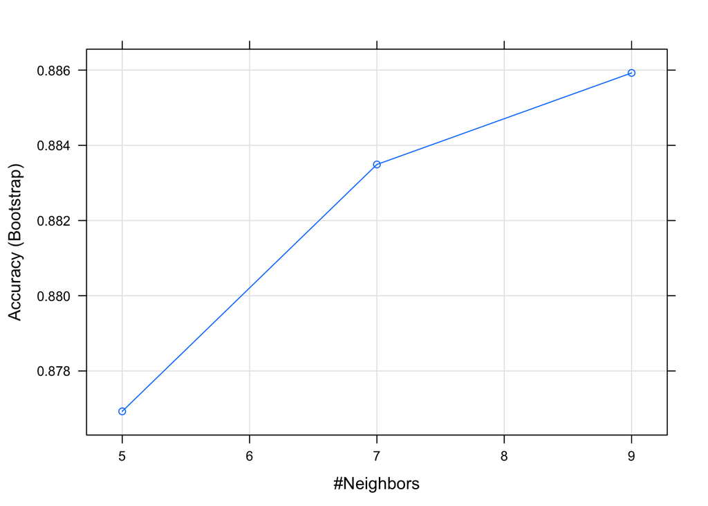

```r
if (file.exists(knn.file)){
  knn = readRDS(knn.file)
} else{
  system.time({
  knn = train(form = y ~., data = train, method = "knn",
                 trControl= trainControl())
  })
  saveRDS(knn, file = "knn.rds")
}


# plot knn
plot(knn)
```

```r
# extract best k
best_k = as.numeric(knn$bestTune)
print(paste0("best k: ", best_k))
```

```
## [1] "best k: 9"
```

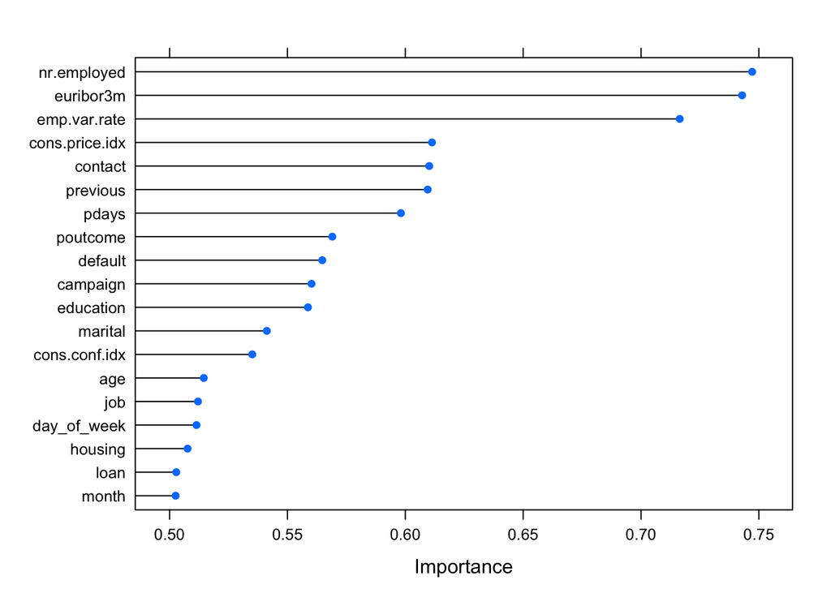

```r
# estimate variable importance
importance.knn = varImp(knn, scale=FALSE)
plot(importance.knn)
```

#### 4. Decision tree

[figure not shown]

```r
if (file.exists(ds.tree.file)){
  ds.tree = readRDS(ds.tree.file)
} else{
  system.time({
  ds.tree = train(form = y ~., data = train, method = "rpart",
                 trControl= trainControl())
  })
  saveRDS(ds.tree, file = "ds_tree.rds")
}


# plot decision tree
fancyRpartPlot(ds.tree$finalModel) # from package "rattle"
```

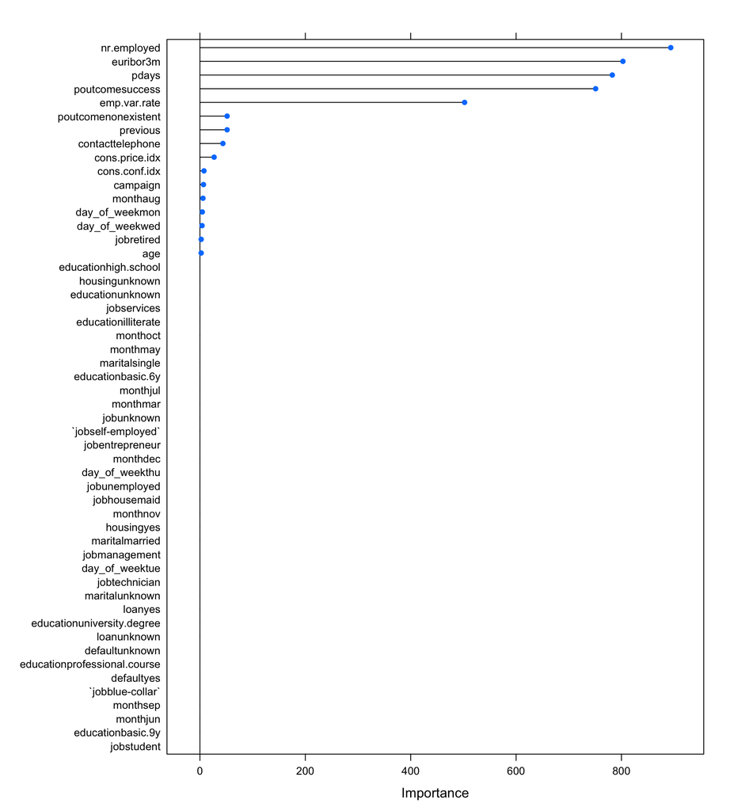

```r
# estimate variable importance
importance.ds.tree = varImp(ds.tree, scale=FALSE)
plot(importance.ds.tree)
```

#### 5. ANN

```r
if (file.exists(ann.file)){
  ann = readRDS(ann.file)
} else{
  system.time({
  ann = train(form = y ~., data = train,
            method = "nnet", trControl = trainControl())
  })
  saveRDS(ann, file = "ann.rds")
}


# best tune: one hidden layer with 5 nodes
best_t = ann$bestTune
print(best_t)
```

```
##   size decay
## 9    5   0.1
```

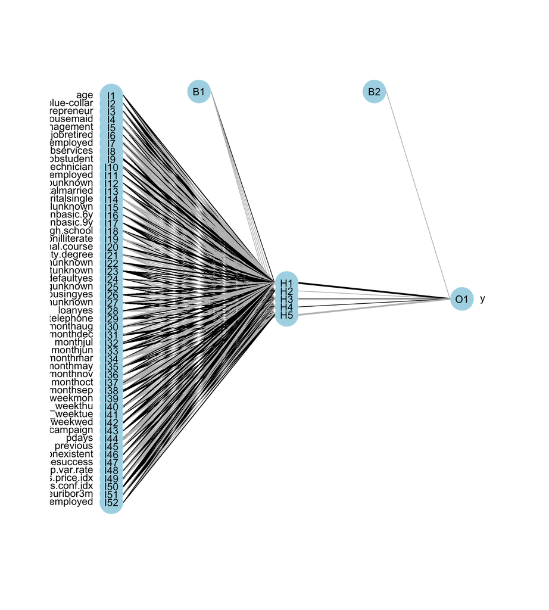

```r
# plot ann
plotnet(ann)
```

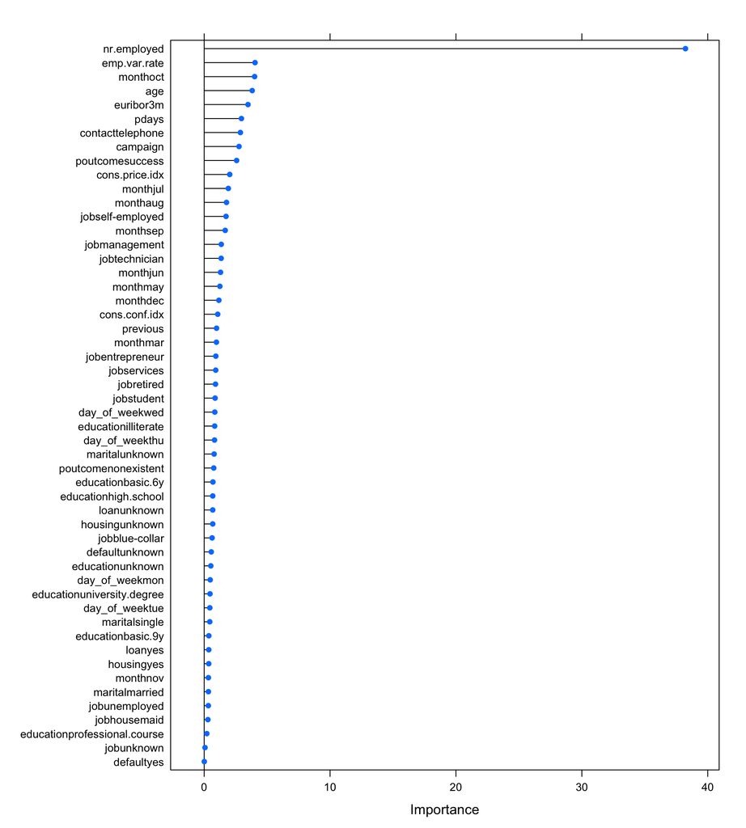

```r
# estimate variable importance
importance.ann = varImp(ann, scale=FALSE)
plot(importance.ann)
```

Summary:  
1. the best k in the kNN model is 9. 2. best tuning factor for ANN is 1 hidden layer with 5 nodes. 3. Comparing variable inportance: the following table displays the highly important variables for each model

| Model | Variables |
| --- | --- |
| logistic regression | `month: March`, `emp.var.rate`, `contact by telephone`, `cons.price.idx` |
| kNN | `nr.employed`, `euribor3m`, `emp.var.rate` |
| Decision tree | `nr.employed`, `euribor3m`, `pdays`, `poutcome: Success`, `emp.var.rate` |
| ANN | `nr.employed` |

Therefore, we can see that variables `nr.employed` and `emp.var.rate` are important factors in predicting whether the customers will subscribe a term deposit or not.

### VIII. Model prediction

```r
# ===================================================
# Logistic regression
# ===================================================
glm.pred = predict(glm.model, test %>% select(-y))
glm.cm <- confusionMatrix(glm.pred, as.factor(test[, "y"]), positive = "yes")
glm.accuracy <- round(as.numeric(glm.cm$overall[1])*100, digits = 2)
glm.kappa <- round(as.numeric(glm.cm$overall[2]), digits = 2)
glm.pred.table <- glm.cm$table
print(glm.pred.table)
```

```
##           Reference
## Prediction    no   yes
##        no  10721  1106
##        yes   172   358
```

```r
# ===================================================
# SVM linear & radial
# ===================================================
svm.linear.pred = predict(svm.linear, test %>% select(-y))
svm.linear.cm <- confusionMatrix(svm.linear.pred, as.factor(test[, "y"]), positive = "yes")
svm.linear.accuracy <- round(as.numeric(svm.linear.cm$overall[1])*100, digits = 2)
svm.linear.kappa <- round(as.numeric(svm.linear.cm$overall[2]), digits = 2)
svm.linear.pred.table <- svm.linear.cm$table
print(svm.linear.pred.table)
```

```
##           Reference
## Prediction    no   yes
##        no  10721  1146
##        yes   172   318
```

```r
svm.radial.pred = predict(svm.radial, test %>% select(-y))
svm.radial.cm <- confusionMatrix(svm.radial.pred, as.factor(test[, "y"]), positive = "yes")
svm.radial.accuracy <- round(as.numeric(svm.radial.cm$overall[1])*100, digits = 2)
svm.radial.kappa <- round(as.numeric(svm.radial.cm$overall[2]), digits = 2)
svm.radial.pred.table <- svm.radial.cm$table
print(svm.radial.pred.table)
```

```
##           Reference
## Prediction    no   yes
##        no  10776  1186
##        yes   117   278
```

```r
# ===================================================
# kNN
# ===================================================
knn.pred = predict(knn, test %>% select(-y))
knn.cm <- confusionMatrix(knn.pred, as.factor(test[, "y"]), positive = "yes")
knn.accuracy <- round(as.numeric(knn.cm$overall[1])*100, digits = 2)
knn.kappa <- round(as.numeric(knn.cm$overall[2]), digits = 2)
knn.pred.table <- knn.cm$table
print(knn.pred.table)
```

```
##           Reference
## Prediction    no   yes
##        no  10649  1051
##        yes   244   413
```

```r
# ===================================================
# Decision tree
# ===================================================
ds.tree.pred = predict(ds.tree, test %>% select(-y))
ds.tree.cm <- confusionMatrix(ds.tree.pred, as.factor(test[, "y"]), positive = "yes")
ds.tree.accuracy <- round(as.numeric(ds.tree.cm$overall[1])*100, digits = 2)
ds.tree.kappa <- round(as.numeric(ds.tree.cm$overall[2]), digits = 2)
ds.tree.pred.table <- ds.tree.cm$table
print(ds.tree.pred.table)
```

```
##           Reference
## Prediction    no   yes
##        no  10744  1132
##        yes   149   332
```

```r
# ===================================================
# ANN
# ===================================================
ann.pred = predict(ann, test %>% select(-y))
ann.cm <- confusionMatrix(ann.pred, as.factor(test[, "y"]), positive = "yes")
ann.accuracy <- round(as.numeric(ann.cm$overall[1])*100, digits = 2)
ann.kappa <- round(as.numeric(ann.cm$overall[2]), digits = 2)
ann.pred.table <- ann.cm$table
print(ann.pred.table)
```

```
##           Reference
## Prediction    no   yes
##        no  10808  1249
##        yes    85   215
```

9. Model Comparison

```r
result.table = data.frame(Model = c("Logistic regression", "SVM Linear", "SVM Radial",
                                    "kNN","Decision tree", "ANN"),
                          Accuracy = c(glm.accuracy, svm.linear.accuracy, svm.radial.accuracy,
                                       knn.accuracy,  ds.tree.accuracy, ann.accuracy),
                          kappa = c(glm.kappa, svm.linear.kappa, svm.radial.kappa,
                                       knn.kappa,  ds.tree.kappa, ann.kappa))
kable(result.table)
```

| Model | Accuracy | kappa |
| --- | --- | --- |
| Logistic regression | 89.66 | 0.32 |
| SVM Linear | 89.33 | 0.28 |
| SVM Radial | 89.46 | 0.26 |
| kNN | 89.52 | 0.34 |
| Decision tree | 89.63 | 0.30 |
| ANN | 89.20 | 0.21 |

There’s no much difference in accuracy and kappa among the models.

### X. Create a stack model

```r
# get predictions from training data
glm.train.pred = predict(glm.model, train %>% select(-y))
```

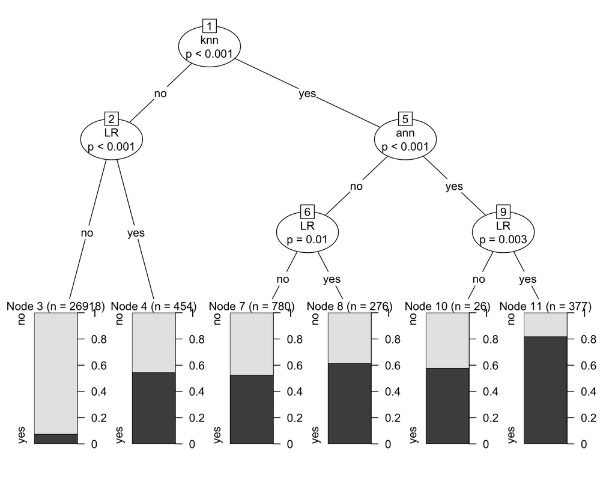

```r
svm.linear.train.pred = predict(svm.linear, train %>% select(-y))
svm.radial.train.pred = predict(svm.radial, train %>% select(-y))
knn.train.pred = predict(knn, train %>% select(-y))
ds.tree.train.pred = predict(ds.tree, train %>% select(-y))
ann.train.pred = predict(ann, train %>% select(-y))

model_combined_results = data.frame(glm.train.pred, svm.linear.train.pred, svm.radial.train.pred , knn.train.pred, ds.tree.train.pred, ann.train.pred, train$y)
colnames(model_combined_results) = c("LR", "smv linear", "svm radial", "knn", "ds tree", "ann", "y")

# create stacking model with ctree

stacked_model = ctree(y ~ . + 1, data = model_combined_results, control = ctree_control(mincriterion = .95))

# plot the model
plot(stacked_model)
```

```r
# create stack data with prediction resulted from testing set
stacked_data = data.frame(glm.pred, svm.linear.pred, svm.radial.pred, knn.pred, ds.tree.pred, ann.pred)
colnames(stacked_data) = c("LR", "smv linear", "svm radial", "knn", "ds tree", "ann")

# predict stack with data with training model
stacked_model_pred = predict(stacked_model, stacked_data)

# confusion matrix
stack.cm = confusionMatrix(stacked_model_pred , as.factor(test[, "y"]), positive = "yes")
stack.accuracy = round(as.numeric(stack.cm$overall[1])*100, digits = 2)
stack.kappa = round(as.numeric(stack.cm$overall[2]), digits = 2)
stack.pred.table <- stack.cm$table
print(stack.pred.table)
```

```
##           Reference
## Prediction    no   yes
##        no  10549   935
##        yes   344   529
```

```r
print(stack.accuracy)
```

```
## [1] 89.65
```

```r
print(stack.kappa)
```

```
## [1] 0.4
```